# McDonalds Data Analysis

[figure not shown]

This project analyzes the nutritional value of the popular restaurant, McDonalds. Roy Kroc, the former CEO of Mcdonalds was an American business man with the dream of creating a fast food restaurant with consistent high quality food. This dataset provides a nutrition analysis of every menu item on the US McDonald's menu, including breakfast, beef burgers, chicken and fish sandwiches, fries, salads, soda, coffee and tea, milkshakes, and desserts. The menu items and nutritional facts were scraped from the McDonald's website.

The McDonald's restaurant has 9 categories in their menu of 260 different items and they are:

- Coffee & Tea
- Breakfast
- Smoothies & Shakes
- Chicken & Fish
- Beverages
- Beef & Pork
- Snacks & Sides
- Desserts
- Salads

Most of McDonald's menu fall under the Coffee and Tea category. The category with the least amount of items is Salads with only 6 items in the Menu.

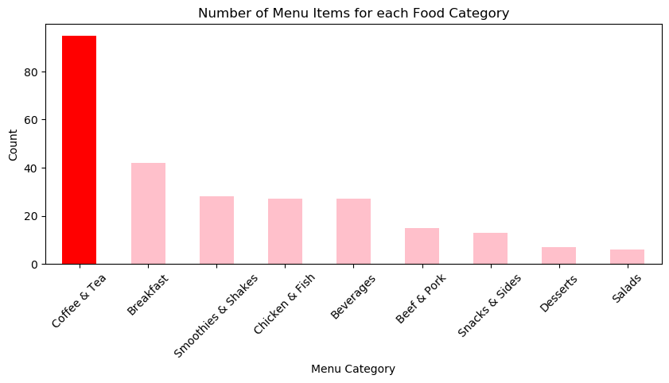

# Fats and Carbohydrates

[figure not shown]

According to the Harvard School of Public Health, instead of promoting foods with low at in calories. It is important to note that healthy fats are not only beneficial but necessary for health. Generally, there is no relationship between the percentage of calories from fat and major health hazard. Fats can be categorized into three:

- Unsaturated Fats. These cateory of fats are good for the health and have a lower disease risk. E.g. Vegetable Oil, Fish, Nuts, Seeds etc.
- Trans Fats These are bad fats and increase disease risk even when consumed in small quantities
- Saturated Fats These are not as harmful as Trans fat bt can be harmful if not taken in moderation. The Dietary Guidlines for America indicates that saturated fat should not be more than 10% of daily calories and the AMA (American Health Association) recommends aiming for a dietary pattern that achieves 5% to 6% of calories from saturated fats.

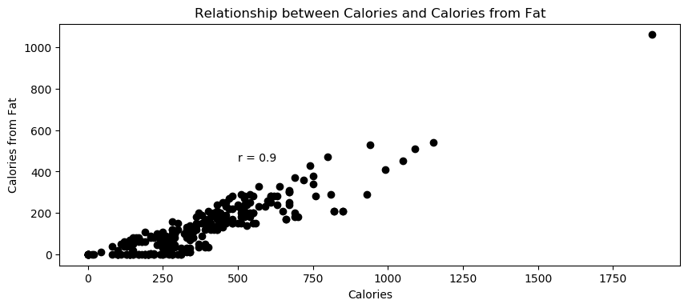

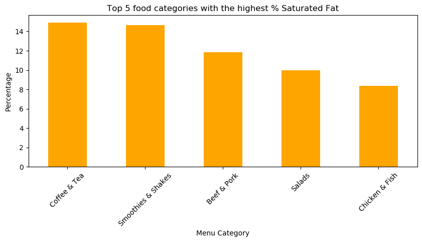

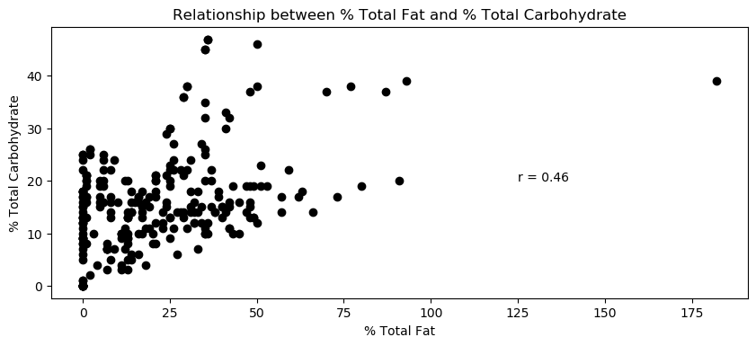

# Vitamins & Minerals

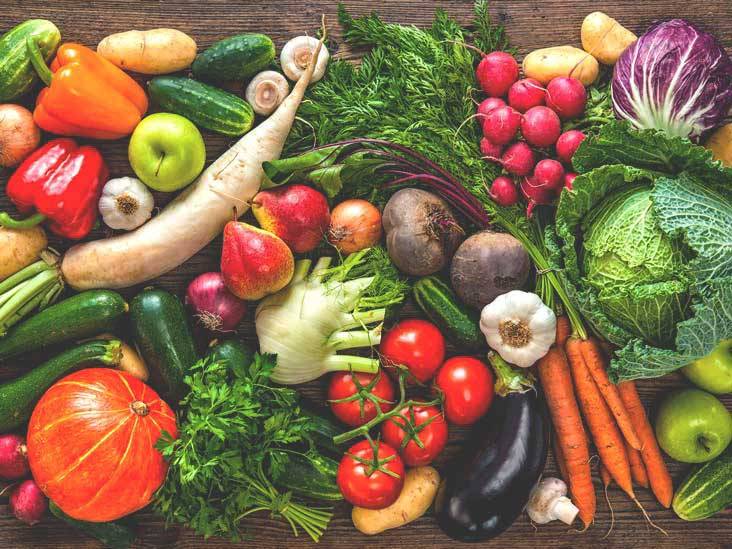

- Vitamin A is an essential vitamin because it protects the eyes, lowers risk of diseases by supporting the immune system, promotes healthy growth etc. Of all the food categories, the Salad category has the highest amount of Vitamin A followed by Chicken & Fish, Smoothies & Shakes.
- Vitamin C is also an essential vitamin useful for boosting immunity, managing high blood pressure etc. Mcdonald's foods are richer in Vitamin A than in Vitamin C. Salads, Snacks and Sides and Beverages are the food categories iwth the highest amount of Vitamin C.
- Apple Slices have the highest amount of Vitamin C in the Snacks category. The Mcdonald's french fries are also rich in Vitamin C because Potato is a rich source of Vitamin C.
- For the beverage category, with the exception of Apple and Orange Juices which have very high Vitamin C content, all the other beverages & drinks (e.g. Coke, Sprite) are very low in Vitamins

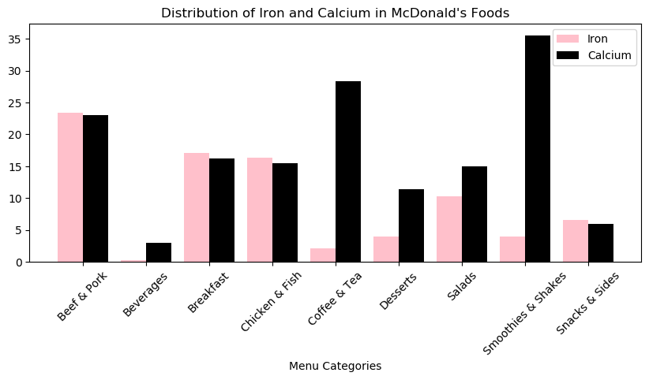

- Shakes (Fruit shakes, milk shakes, chocolate shakes etc.) are rich in Calcium but low in Iron. The Coeffee & Tea category is also rich in Calcium but low in Iron.
- Menu categories rich in Animal protein (Beef & Pork, Chicken & Fish) are rich in both Iron and Calcium
- Mcdonald's beverages are low in Calcium and Iron.

# Summary

This analysis provides a walkthrough the McDonald's Menu list and the nutritional value of each food category in the list. Based on this analysis, you can decide which food to opt for based on your preference or nutritional needs.

A lot of Mcdonald's foods are rich in Vitamins (Vitamin A & C) especially Salads. Also, most foods are low in carbohydrate with little or no trans-fat which is a plus. However, a lot of foods are high in Saturated fat, hence, it is important to check for foods with low Saturated fat (>10%) in case you are cutting on your fat intake.The analysis also covers essential minerals such as Calcium and Iron and it was noted that foods in the menu containing milk or animal protein are very rich in calcium.